# ¿A dónde va un peruano cuando se enferma?

Un análisis de salud de la ENAHO 2023

Autor/a

Afiliación

Alexander Pereda Escalante

Universidad Nacional Mayor de San Marcos

Fecha de publicación

8 de enero de 2025

# Introducción

En el Perú, el sector salud debe trabajar estrechamente con los datos para implementar reformas adecuadas que beneficien a los ciudadanos. La información proveniente de encuestas de hogares constituye un recurso valioso que podemos utilizar para obtener insights significativos.

En este trabajo haremos un análisis sobre una pregunta muy común: ¿A dónde acudimos cuando nos sentimos enfermos?

Agruparemos a la población peruana en cuatro zonas geográficas:

- Norte: Tumbes, Piura, Lambayeque, Cajamarca, La Libertad y Amazonas.
- Sur: Ayacucho, Cusco, Apurímac, Arequipa, Puno, Moquegua y Tacna.
- Oriente: Loreto, San Martín, Ucayali y Madre de Dios.
- Centro: Áncash, Huánuco, Pasco, Junín, Huancavelica, Ica, Callao y Lima.

Nos proponemos a responder las siguientes preguntas:

1. ¿Cómo están distribuidas las personas que presentaron algún malestar en el Perú según la zona geográfica?
2. ¿Cómo varían las preferencias de las personas que presentan algún malestar según la zona en que se ubican?
3. ¿Qué establecimientos visitan más?

La información general del proyecto es la siguiente:

- Fuente de datos: Módulo 400 de ENAHO 2023, obtenido de la página de [microdatos de INEI](https://proyectos.inei.gob.pe/microdatos/), y “Límites departamentales” obtenido de la página de [datos abiertos del Perú](https://www.datosabiertos.gob.pe/dataset/limites-departamentales).
- Entorno de trabajo: Visual Studio Code.
- Lenguaje de programacion: R.
- Formato: El documento se realizó en Quarto, y se adoptó un enfoque narrativo para los resultados. Los archivos están debidamente comentados y siguen buenas prácticas para garantizar la reproducibilidad.

PSDT: se recomienda mucho leer la [ficha técnica](https://proyectos.inei.gob.pe/iinei/srienaho/Descarga/FichaTecnica/906-Ficha.pdf), toda la información relevante sobre ENAHO se encuentra allí.

# Importación de los datos

En la página de microdatos del INEI, buscamos la encuesta ENAHO 2023 y descargamos el [módulo 400 (salud)](https://proyectos.inei.gob.pe/iinei/srienaho/descarga/STATA/906-Modulo04.zip).

Este módulo contiene información sobre el ubigeo, si la persona experimentó malestar, a dónde acudió en caso de sentirse mal, entre otros datos. Nosotros extraeremos únicamente las columnas necesarias.

Módulo 400 - ENAHO 2023

| ubigeo | p4025 | p4031 | p4032 | p4033 | p4034 | p4035 | p4036 | p4037 | p4038 | p4039 | p40310 | p40311 | p40313 | p40314 |
| --- | --- | --- | --- | --- | --- | --- | --- | --- | --- | --- | --- | --- | --- | --- |
| 010201 | 0 | 0 | 0 | 0 | 0 | 0 | 1 | 0 | 0 | 0 | 0 | 0 | 0 | 0 |
| 010201 | 0 | 0 | 0 | 0 | 0 | 1 | 0 | 0 | 0 | 0 | 0 | 0 | 0 | 0 |
| 010201 | 0 | 0 | 0 | 0 | 0 | 0 | 0 | 0 | 0 | 0 | 0 | 0 | 0 | 1 |
| 010201 | 1 | NA | NA | NA | NA | NA | NA | NA | NA | NA | NA | NA | NA | NA |
| 010201 | 1 | NA | NA | NA | NA | NA | NA | NA | NA | NA | NA | NA | NA | NA |
| 010201 | 0 | 0 | 0 | 0 | 0 | 0 | 0 | 0 | 0 | 0 | 0 | 0 | 0 | 1 |
| 010201 | 1 | NA | NA | NA | NA | NA | NA | NA | NA | NA | NA | NA | NA | NA |
| 010201 | 1 | NA | NA | NA | NA | NA | NA | NA | NA | NA | NA | NA | NA | NA |
| 010201 | 1 | NA | NA | NA | NA | NA | NA | NA | NA | NA | NA | NA | NA | NA |
| 010201 | 0 | 0 | 0 | 0 | 0 | 0 | 0 | 0 | 0 | 0 | 0 | 0 | 0 | 1 |

A continuación una tabla para describir los datos:

| Variable | Descripción |
| --- | --- |
| Ubigeo | Ubicación geográfica |
| p4025 | ¿Presentó algún malestar en las últimas 4 semanas? (1: No / 0: Sí) |
| p4031 | Acudió al “Puesto de salud MINSA” a consultar por el malestar (1: Sí / 0: No) |
| p4032 | Acudió al “Centro de salud MINSA” a consultar por el malestar (1: Sí / 0: No) |
| p4033 | Acudió al “Centro o puesto de salud CLAS” a consultar por el malestar (1: Sí / 0: No) |
| p4034 | Acudió a “Posta, policlínico, EsSalud” a consultar por el malestar (1: Sí / 0: No) |
| p4035 | Acudió al “Hospital MINSA” a consultar por el malestar (1: Sí / 0: No) |
| p4036 | Acudió al “Hospital del Seguro (EsSalud)” a consultar por el malestar (1: Sí / 0: No) |
| p4037 | Acudió al “Hospital de las FF.AA y/o Policia Nacional” a consultar por el malestar (1: Sí / 0: No) |
| p4038 | Acudió al “Consultorio médico particular” a consultar por el malestar (1: Sí / 0: No) |
| p4039 | Acudió a “Clínica particular” a consultar por el malestar (1: Sí / 0: No) |
| p40310 | Acudió a “Farmacia o botica” a consultar por el malestar (1: Sí / 0: No) |
| p40311 | Acudió a “En su domicilio (del paciente)” a consultar por el malestar (1: Sí / 0: No) |
| p40313 | Acudió al “Otro” a consultar por el malestar (1: Sí / 0: No) |
| p40314 | No buscó atención (1: No buscó atención / 0: No) |

# Preprocesamiento

Iniciamos observando la cantidad de valores faltantes según `zona`.

| zona | total | porcentaje_missings | porcentaje_total |
| --- | --- | --- | --- |
| Centro | 34 | 32.380952 | 0.030214165 |
| Norte | 16 | 15.238095 | 0.014218431 |
| Oriente | 8 | 7.619048 | 0.007109215 |
| Sur | 47 | 44.761905 | 0.041766640 |

Observamos:

- El Sur presenta la mayor tasa de valores faltantes (44.8%), seguido del Centro (32%).
- El Norte y Oriente presentan tasas bajas (15% y 7%, respectivamente).
- Hay 105 valores faltantes, que representan el 0.092% de nuestros datos
- Dado que los datos faltantes son tan pocos, podemos eliminarlos.

Además, como solo nos interesan los casos de personas enfermas, filtramos la información para quedarnos solo con ese sector.

# Análisis

Ya estamos en condiciones de dar respuesta a nuestras tres interrogantes.

Primero, veamos la distribución de los datos. Para ello, nos valemos de una tabla y un mapa.

Tabla de frecuencias

| zona | conteo | porcentaje |
| --- | --- | --- |
| Centro | 25616 | 40.61133 |
| Norte | 14137 | 22.41265 |
| Oriente | 8688 | 13.77386 |
| Sur | 14635 | 23.20217 |

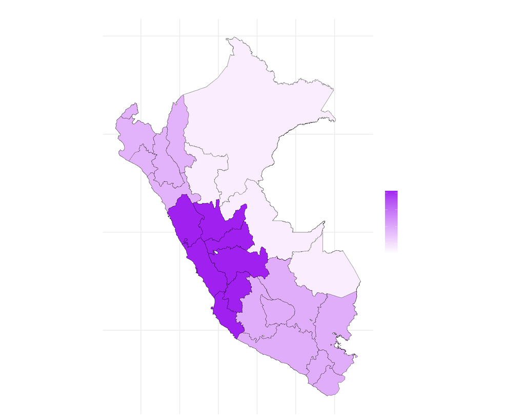

Elaboración propia. Fuente: Enaho 2023, Módulo 400

## Pregunta 1

#### ¿Cómo están distribuidas las personas que presentaron algún malestar en el Perú según la zona geográfica?

Se observa lo siguiente:

- La zona Centro tiene la mayor concentración de individuos (40%).
- Las zonas Norte y Sur tienen cantidades bastante semejantes (aproximadamente 23%).
- Oriente cuenta con un 13% de la población afectada.

## Pregunta 2

#### ¿Cómo varían las preferencias de las personas que presentan algún malestar según la zona en que se ubican?

El siguiente gráfico nos da la respuesta.

Preferencias de la población con malestar según zona.

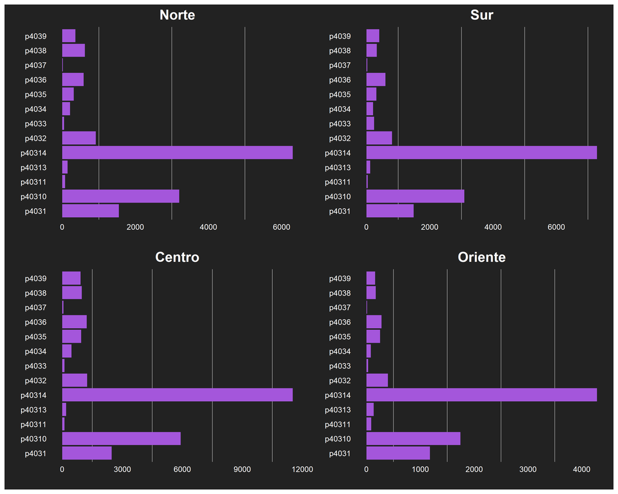

Elaboración propia. Fuente: Enaho 2023, Módulo 400

Las 4 zonas tienen comportamientos muy semejantes, con ligeras variaciones para algunas variables. Podemos decir que las preferencias de las personas enfermas es *quasi-uniforme*.